# Lesson 3

Notes:

## Reading in Data

### Pseudo-Facebook User Data

```r
pf <- read.csv("pseudo_facebook.tsv", sep = '\t')
names(pf)
```

```
##  [1] "userid"                "age"
##  [3] "dob_day"               "dob_year"
##  [5] "dob_month"             "gender"
##  [7] "tenure"                "friend_count"
##  [9] "friendships_initiated" "likes"
## [11] "likes_received"        "mobile_likes"
## [13] "mobile_likes_received" "www_likes"
## [15] "www_likes_received"
```

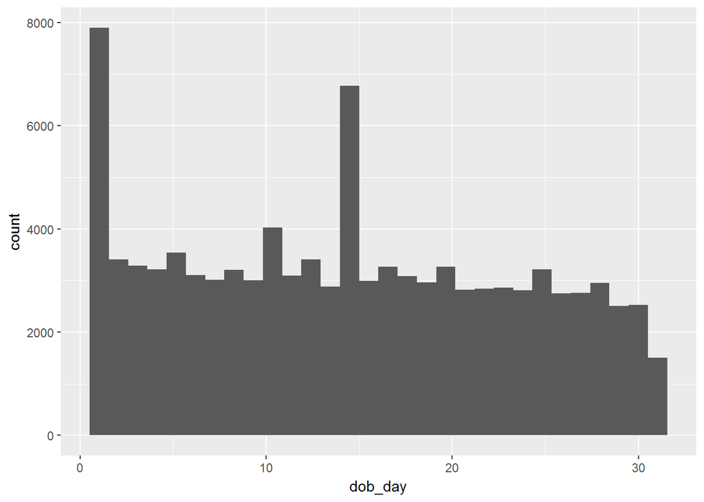

```r
# Installed ggplot2

library(ggplot2)
qplot(x = dob_day, data = pf)
```

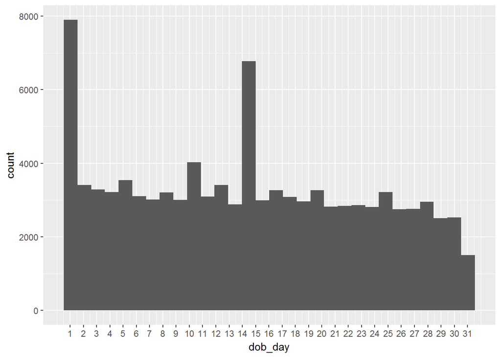

```r
qplot(x = dob_day, data = pf) +
  scale_x_continuous(breaks = 1:31)
```

```r
# Getting error here
```

Instead of using the qplot() function, you can also use the ggplot() function to create the histogram:

[figure not shown]

```r
ggplot(aes(x = dob_day), data = pf) +
  geom_histogram(binwidth = 1) +
  scale_x_continuous(breaks = 1:31)
```

### Faceting

Notes:

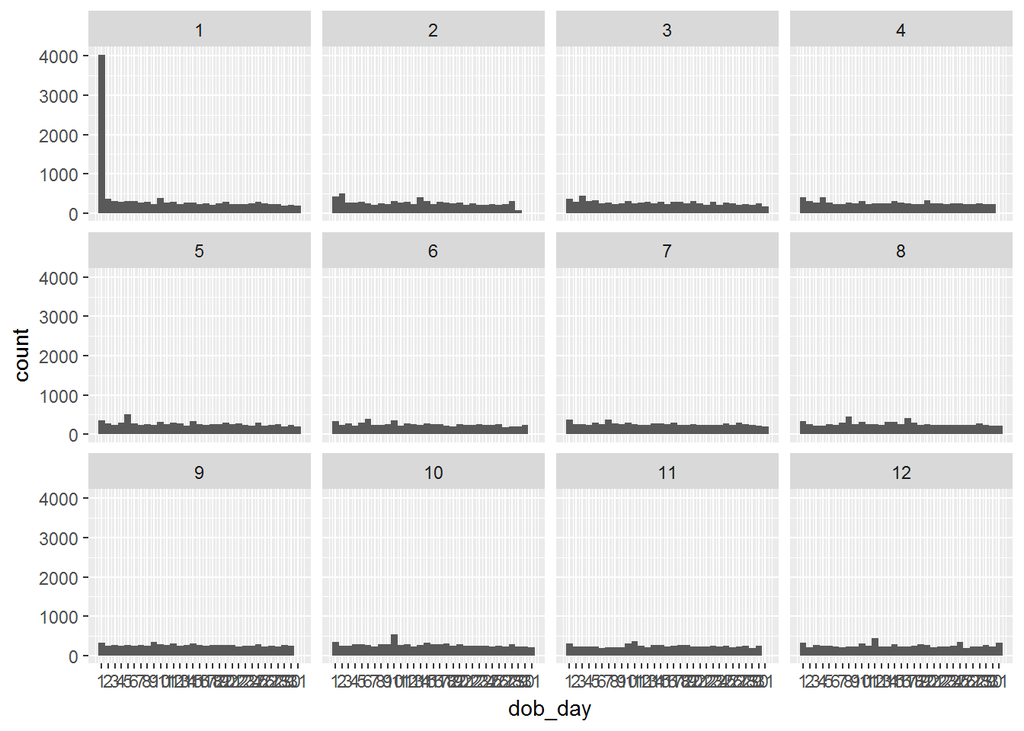

```r
ggplot(data = pf, aes(x = dob_day)) +
  geom_histogram(binwidth = 1) +
  scale_x_continuous(breaks = 1:31) +
  facet_wrap(~dob_month, ncol=4)
```

### Friend Count

Notes:

#### What code would you enter to create a histogram of friend counts?

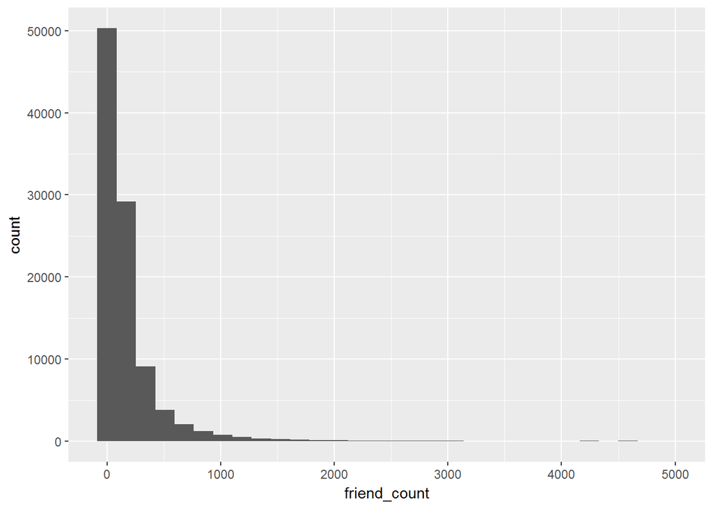

```r
ggplot(data = pf, aes(x = friend_count))+
  geom_histogram()
```

#### How is this plot similar to Moira’s first plot?

Response: Data is squished on left side of graph and it decrease toward the 5000 mark. The data is long tailed data. So most users have friends under 500

### Limiting the Axes

Notes:

```
## Warning: Removed 2951 rows containing non-finite values (stat_bin).
```

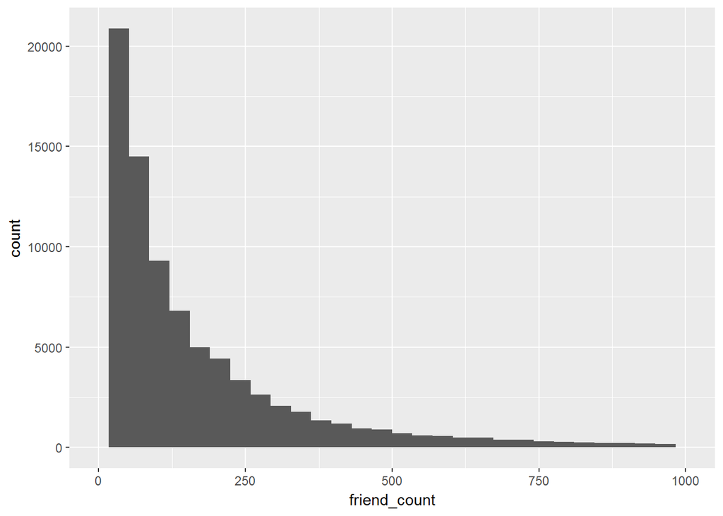

```r
# Using the Q-plot syntax
qplot(x = friend_count, data = pf, xlim = c(0,1000))
```

```r
#qplot(x = friend_count, data = pf) +
#  scale_x_continuous(limits = c(0,1000))


#ggplot(data = pf, aes(x = friend_count))+
#  geom_histogram() +
#  scale_x_continuous(limits = c(0,1000))
```

### Exploring with Bin Width

Notes: To remove the warning : __ `stat_bin()` using `bins = 30`. Pick better value with `binwidth`.__

```
## Warning: Removed 2951 rows containing non-finite values (stat_bin).
```

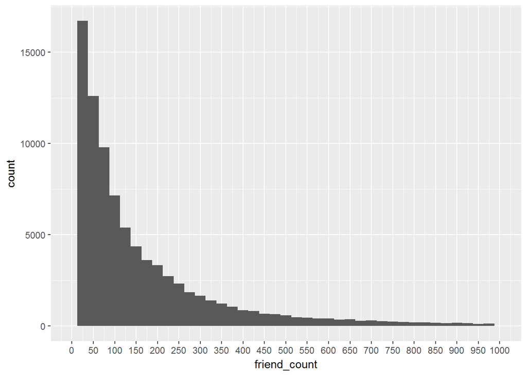

```r
qplot(x = friend_count, data = pf, binwidth = 25) +
  scale_x_continuous(limits = c(0, 1000),
                     breaks = seq(0, 1000, 50))
```

Equivalent ggplot syntax: Just changed binwidth to 50.

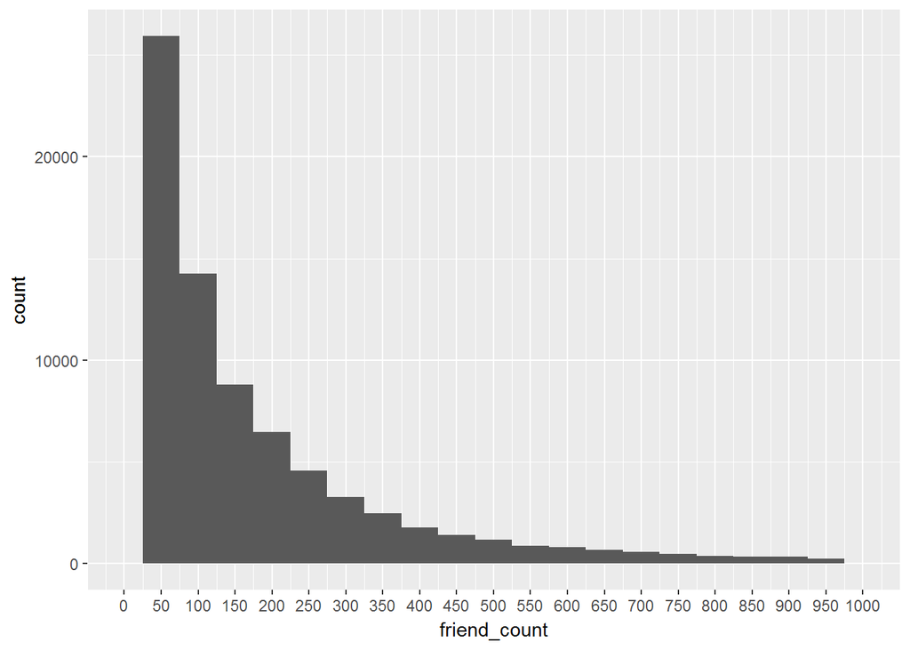

```r
ggplot(aes(x = friend_count), data = pf) +
  geom_histogram(binwidth = 50) +
  scale_x_continuous(limits = c(0, 1000), breaks = seq(0, 1000, 50))
```

### Adjusting the Bin Width

Notes:

### Faceting Friend Count

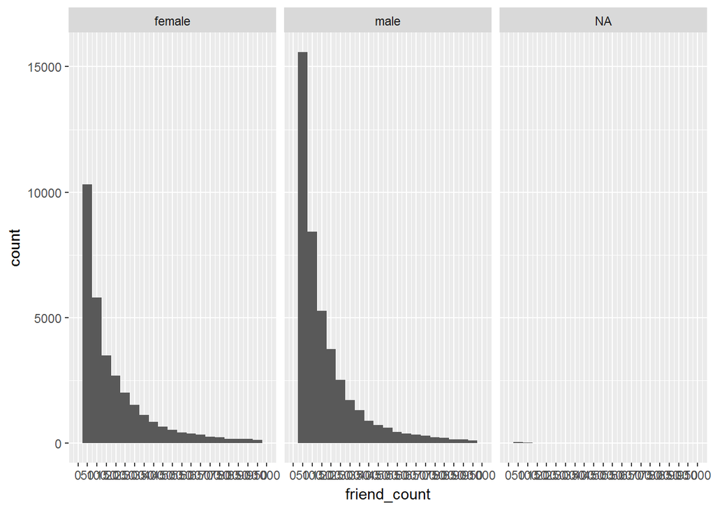

```r
# What code would you add to create a facet the histogram by gender?
# i.e., Which gender group has friends?
# Add it to the code below.
ggplot(aes(x = friend_count), data = pf) +
  geom_histogram(binwidth = 50) +
  scale_x_continuous(limits = c(0, 1000), breaks = seq(0, 1000, 50)) +
  facet_wrap(~gender)
```

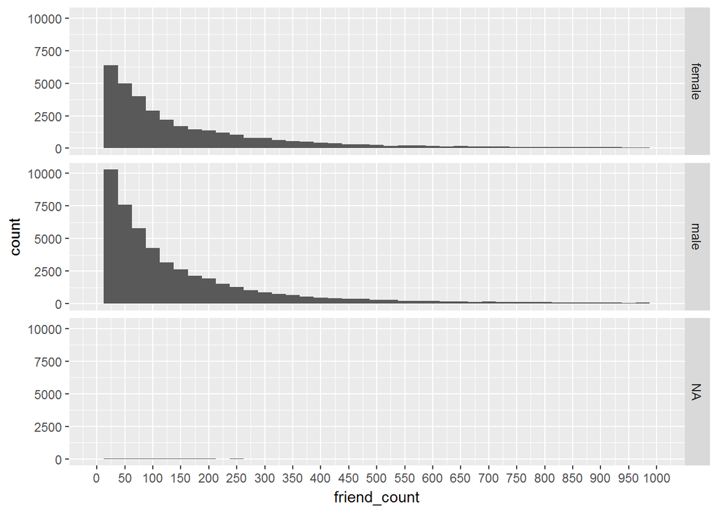

```r
qplot(x = friend_count, data = pf, binwidth = 25) +
  scale_x_continuous(limits = c(0, 1000),
                     breaks = seq(0, 1000, 50)) +
  facet_grid(gender ~ .)
```

### Omitting NA Values

Notes:

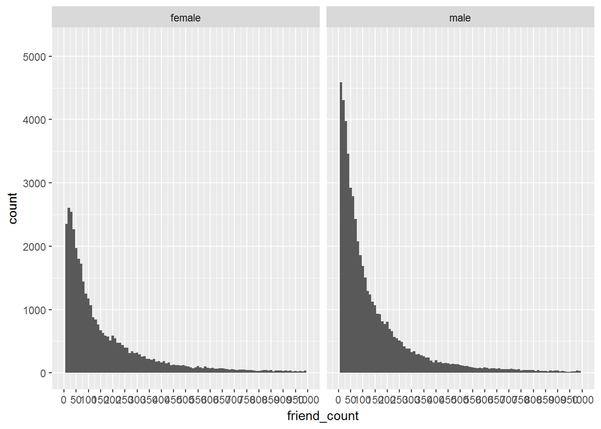

```r
qplot(x = friend_count, data = subset(pf, !is.na(gender)), binwidth = 10) +
  scale_x_continuous(lim = c(0,1000), breaks = seq(0,1000,50))+
  facet_wrap( ~ gender)
```

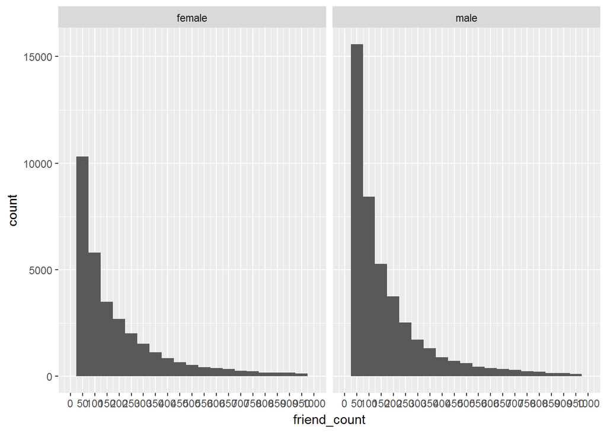

```r
ggplot(aes(x = friend_count), data = subset(pf, !is.na(gender))) +
  geom_histogram(binwidth=50) +
  scale_x_continuous(limits = c(0, 1000), breaks = seq(0, 1000, 50)) +
  facet_wrap(~gender)
```

### Statistics ‘by’ Gender

```r
table(pf$gender)
```

```
##
## female   male
##  40254  58574
```

```r
by(pf$friend_count, pf$gender, summary)
```

```
## pf$gender: female
##    Min. 1st Qu.  Median    Mean 3rd Qu.    Max.
##       0      37      96     242     244    4923
## --------------------------------------------------------
## pf$gender: male
##    Min. 1st Qu.  Median    Mean 3rd Qu.    Max.
##       0      27      74     165     182    4917
```

#### Who on average has more friends: men or women?

Response: Female

#### What’s the difference between the median friend count for women and men?

Response: 22

Notice mean for friend_count for both male and female is greater than the median as the data we use is **long-tailed** so the higher values will pull the mean to right.

#### Why would the median be a better measure than the mean?

Response: Median is a better measure than mean because it is a more robust statistic. A few people will more friends count drag the means upwards which is not representative of most users. But median is resistive to change as it marks the halfway point for all data points.

### Tenure

Notes: i.e., How may days i have been using facebook??

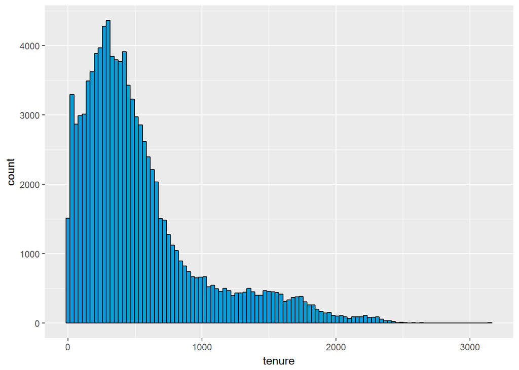

```r
qplot(x = tenure, data = pf, binwidth = 30,
      color = I('black'), fill = I('#099DD9'))
```

The color to be fill must be in Hex code find it from wikipedia page on [Web colors](https://en.wikipedia.org/wiki/Web_colors).

Using ggplot:

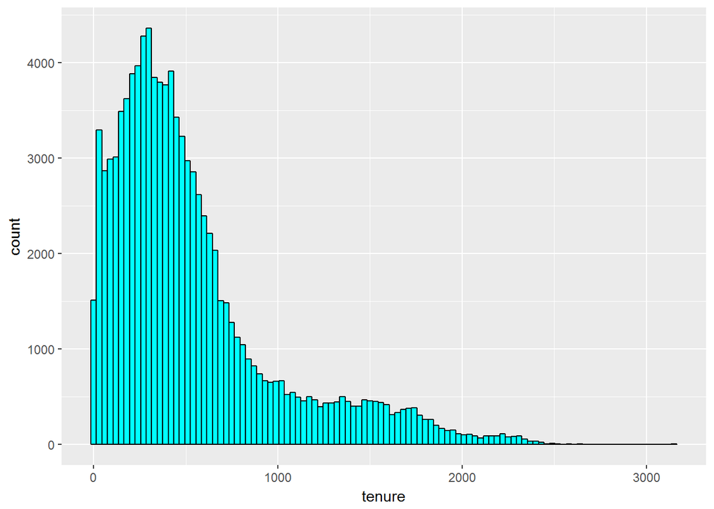

```r
ggplot(aes(x = tenure), data = pf) +
  geom_histogram(binwidth = 30, color = 'black', fill = '#00FFFF')
```

#### How would you create a histogram of tenure by year?

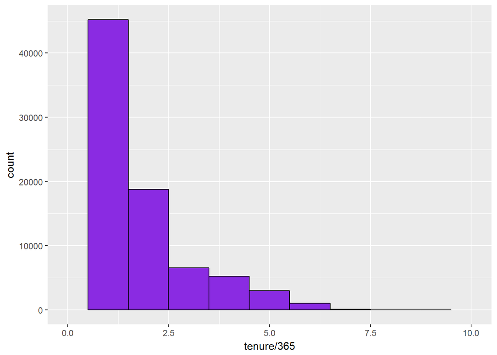

```r
qplot(x = tenure/365, data = pf, binwidth=1,xlim = c(0,10),
      color = I('black'), fill = I('#8A2BE2'))
```

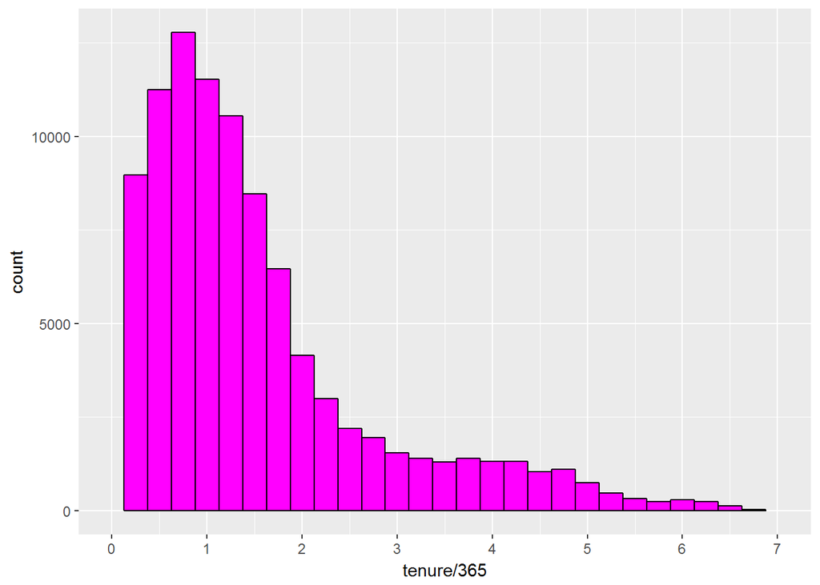

```r
ggplot(aes(x = tenure/365), data = pf) +
  geom_histogram(binwidth = .25, color = 'black', fill = '#FF00FF')+
  scale_x_continuous(limits = c(0,7), breaks = seq(0,7,1))
```

### Labeling Plots

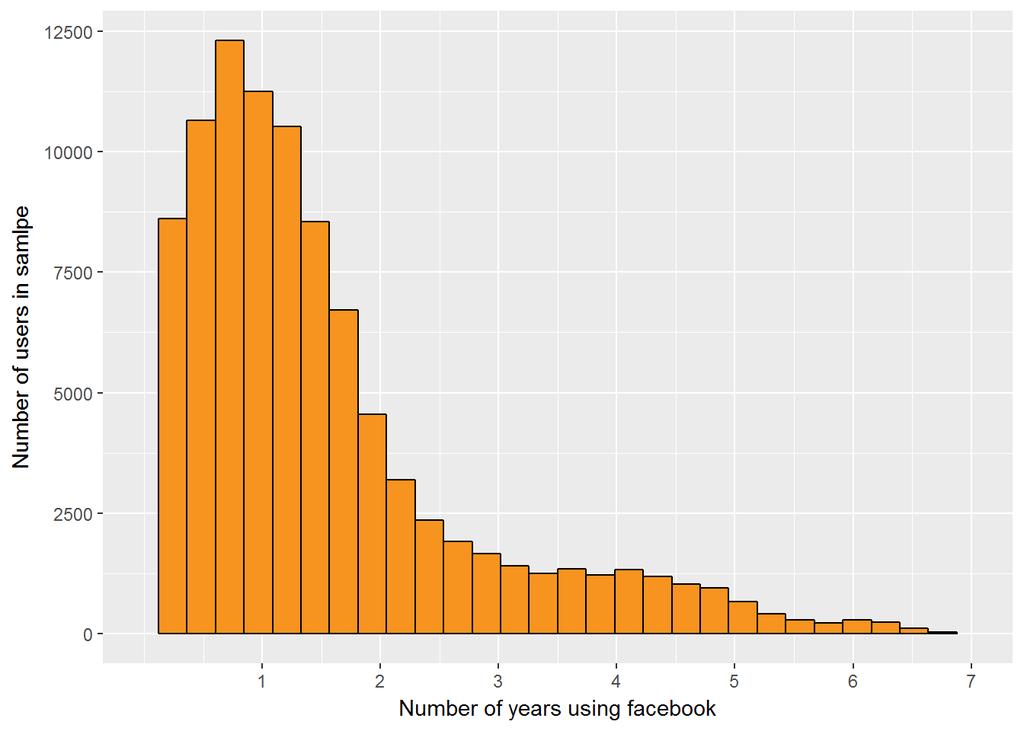

```r
qplot(x = tenure/365, data = pf,
      xlab = "Number of years using facebook",
      ylab = "Number of users in samlpe",
      color = I('black'), fill = I('#F79420')) +
  scale_x_continuous(breaks = seq(1,7,1), lim = c(0,7))
```

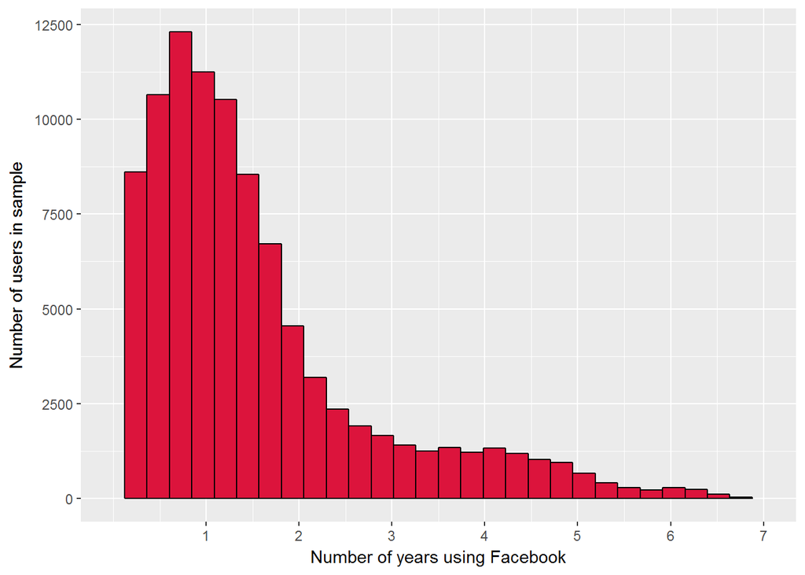

```r
ggplot(aes(x = tenure / 365), data = pf) +
  geom_histogram(color = 'black', fill = '#DC143C') +
  scale_x_continuous(breaks = seq(1, 7, 1), limits = c(0, 7)) +
  xlab('Number of years using Facebook') +
  ylab('Number of users in sample')
```

### User Ages

Notes: Finding histogram of user ages

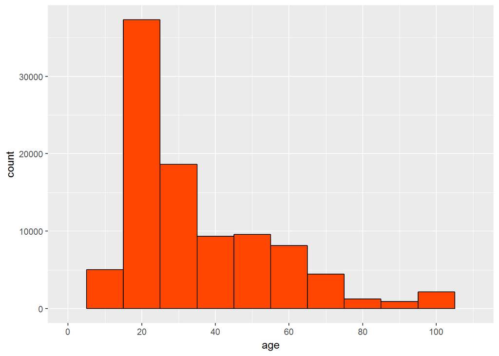

```r
qplot(x = age, data =pf, binwidth = 10,

      color = I('black'), fill = I('#FF4500')) +
  scale_x_continuous(breaks = seq(0,110,20), lim = c(0,110))
```

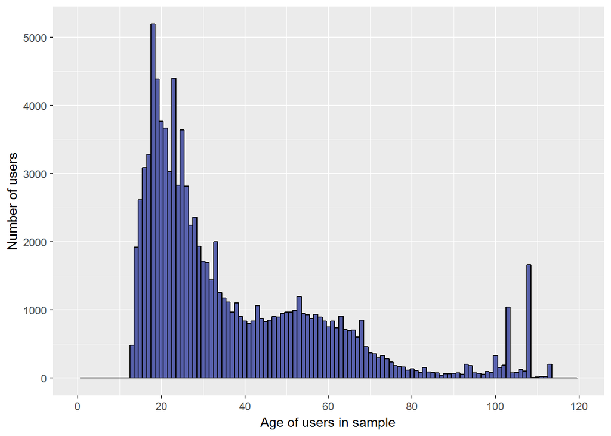

```r
ggplot(aes(x = age), data = pf) +
  geom_histogram(binwidth = 1, color = 'black', fill = '#5760AB') +
  scale_x_continuous(breaks = seq(0,120,20), limits = c(0,120)) +
  xlab("Age of users in sample") +
  ylab("Number of users")
```

### Transforming Data

Notes:

1. Using **ggplot** :

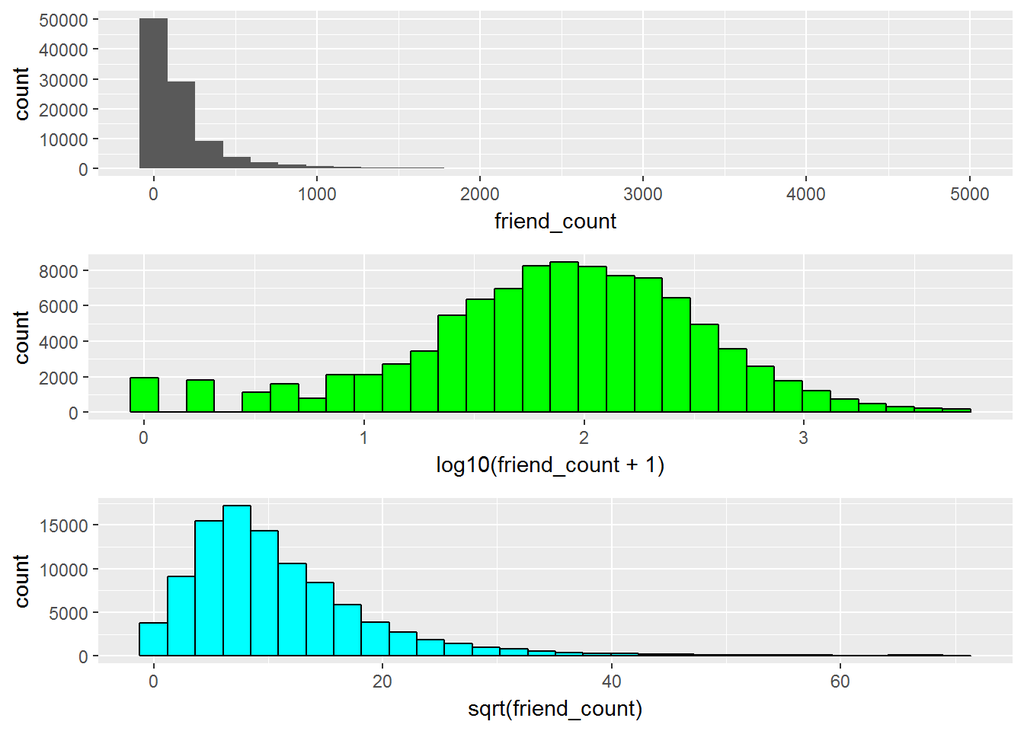

```r
library(gridExtra)
library(grid)

p1 <- ggplot(aes(x = friend_count), data = pf) +
  geom_histogram()

p2 <- ggplot(aes(x = log10(friend_count + 1)), data = pf) +
  geom_histogram(color = 'black', fill = '#00FF00')



p3 <- ggplot(aes(x = sqrt(friend_count)), data = pf) +
  geom_histogram(color = 'black', fill = '#00FFFF')

grid.arrange(p1,p2,p3,ncol=1)
```

2. Using **qplot()**:

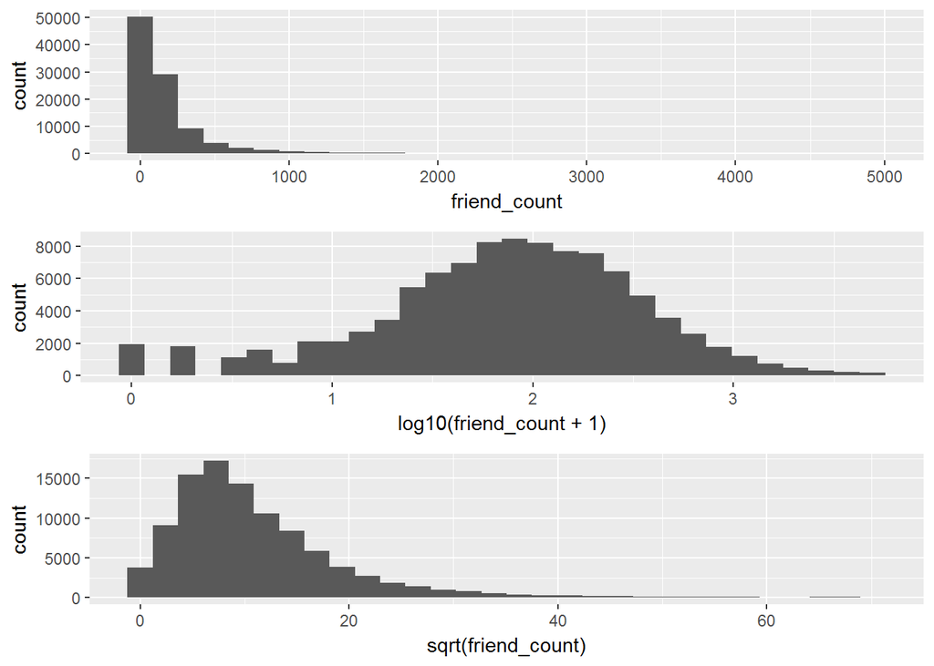

```r
p4 <- qplot(x = friend_count, data = pf)
p5 <- qplot(x = log10(friend_count + 1), data = pf)
p6 <- qplot(x = sqrt(friend_count), data = pf)

grid.arrange(p4,p5,p6,ncol=1)
```

### Add a Scaling Layer

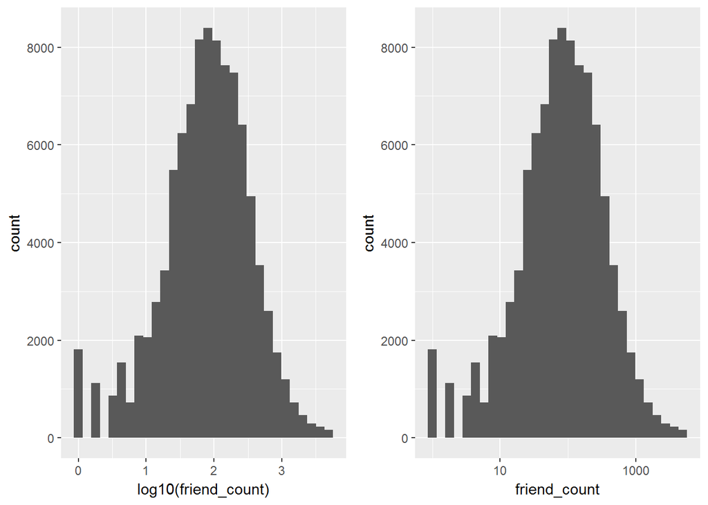

```r
logScale <- qplot(x = log10(friend_count), data = pf)

countScale <- ggplot(aes(x = friend_count), data = pf) +
  geom_histogram() +
  scale_x_log10()

grid.arrange(logScale, countScale, ncol = 2)
```

Notes: Running the code we see the 2 histograms and observe that the difference is in the x-axis labelling: **log10() wrapper** will label the x-axis in log units. Using **scale_x_log10()** will label the x-axis in actual friend_count.

scale_x_log10() is equivalent to scale_x_continuous(trans = “log10”). They both support a common set of continuous scale parameters. If you have specified both scales for a plot, the latter one will replace the existing one.

### Frequency Polygons

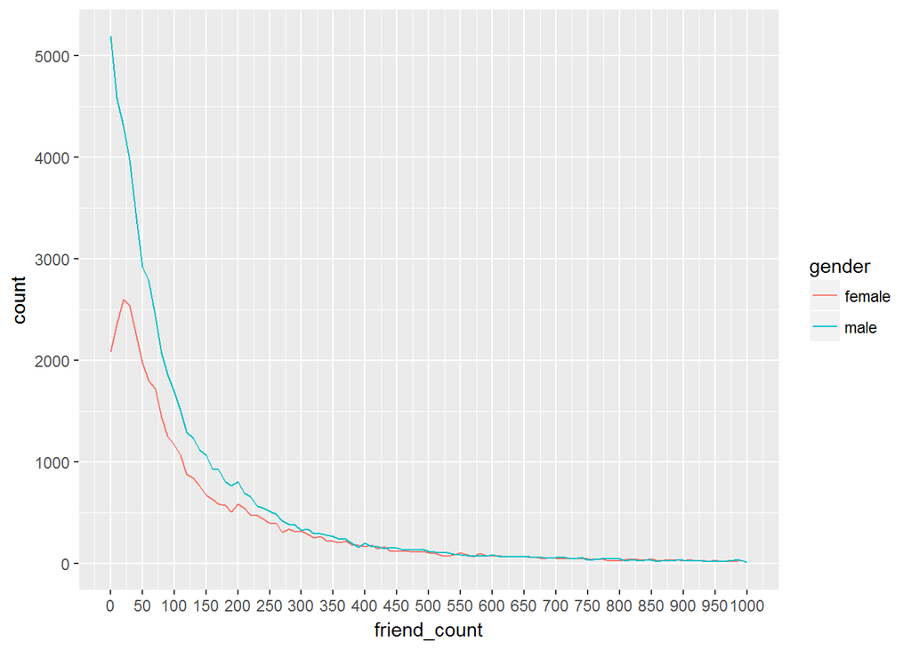

```r
qplot(x = friend_count, data = subset(pf,!is.na(gender)), binwidth = 10,
      geom = 'freqpoly',color = gender) +
  scale_x_continuous(breaks = seq(0,1000,50), lim = c(0,1000))
```

But this plot doesn’t tell who has more friends on avg men/women. Let’s change the y-axis to show proportion instead of counts.

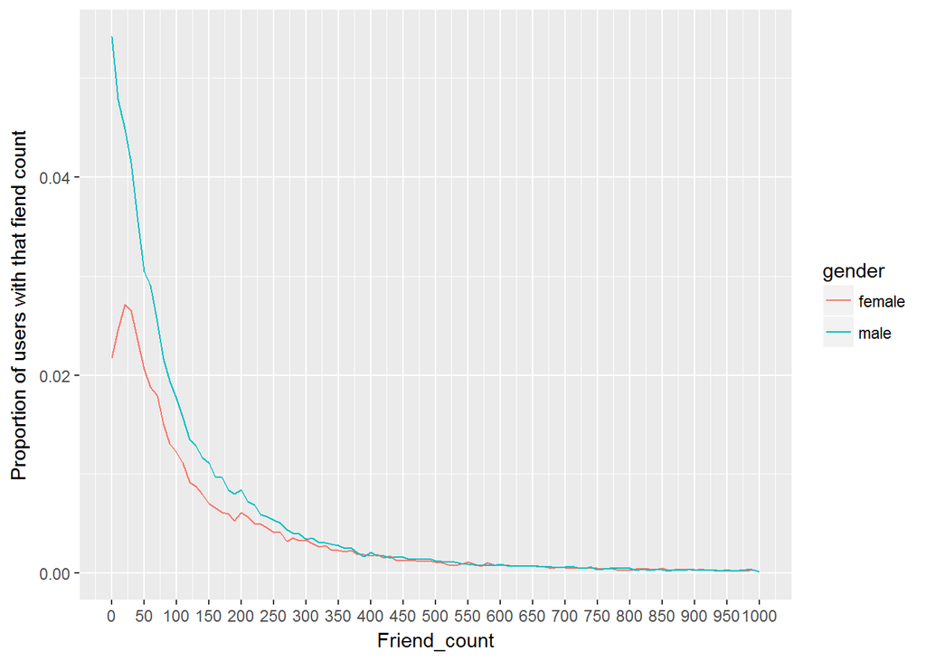

```r
qplot(x = friend_count, y = ..count../sum(..count..),
      data = subset(pf,!is.na(gender)), binwidth = 10,
      xlab = 'Friend_count',
      ylab = 'Proportion of users with that fiend count',
      geom = 'freqpoly',
      color = gender) +
  scale_x_continuous(breaks = seq(0,1000,50), lim = c(0,1000))
```

From the graph we infer that many males have low friend counts its at tail region of graph females overtake men.

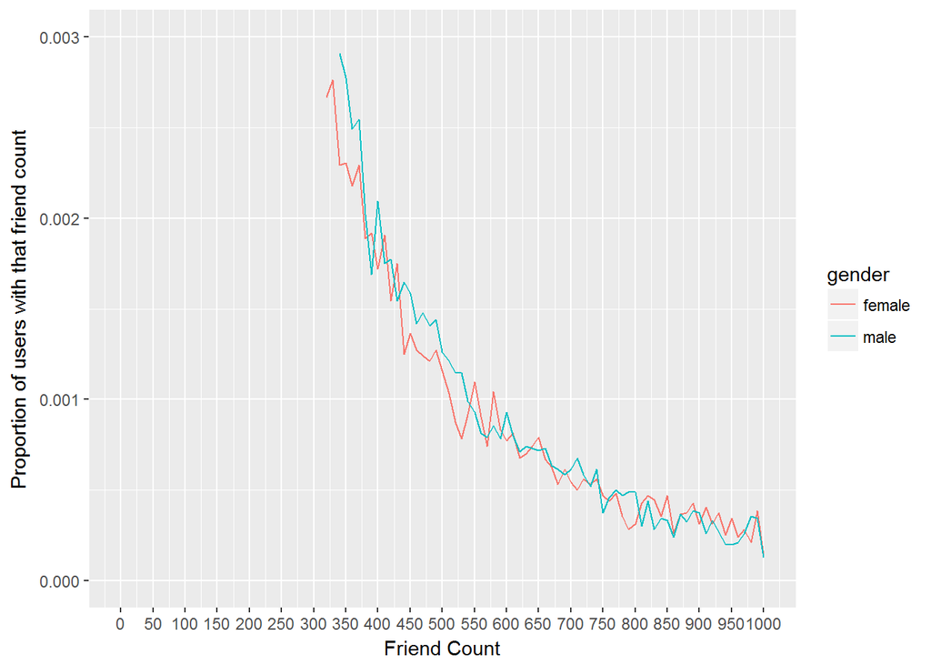

```r
ggplot(aes(x = friend_count, y = ..count../sum(..count..)),
       data = subset(pf, !is.na(gender))) +
  geom_freqpoly(aes(color = gender), binwidth=10) +
  scale_x_continuous(limits = c(0, 1000), breaks = seq(0, 1000, 50)) +
  scale_y_continuous(limits = c(0,0.003)) +
  xlab('Friend Count') +
  ylab('Proportion of users with that friend count')
```

Note that sum(..count..) will sum across color, so the proportions displayed are based on total users. To plot these proportions within each group, you can try y = ..density..

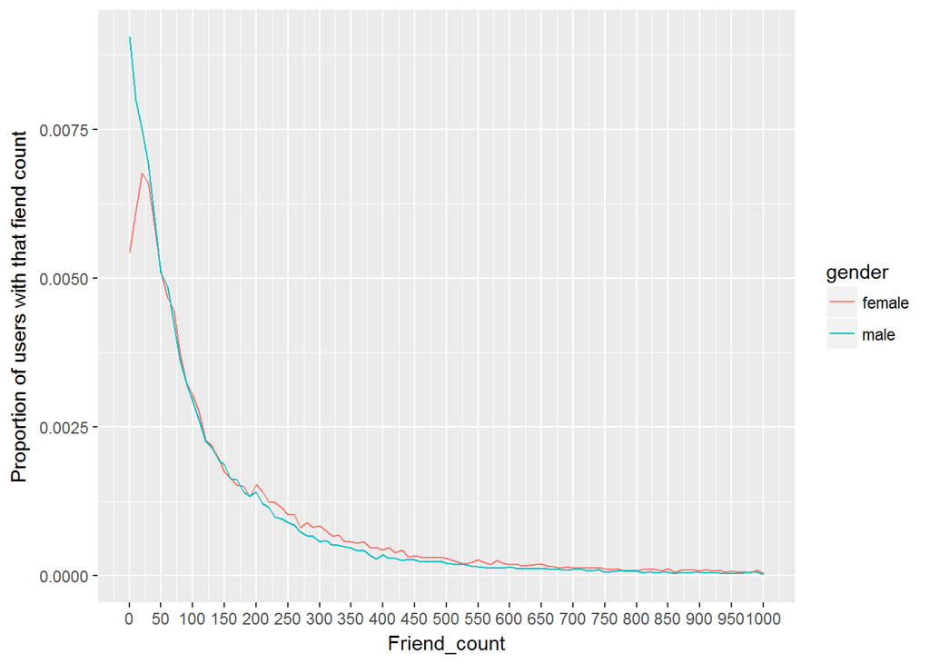

```r
qplot(x = friend_count, y = ..density..,
      data = subset(pf,!is.na(gender)), binwidth = 10,
      xlab = 'Friend_count',
      ylab = 'Proportion of users with that fiend count',
      geom = 'freqpoly',
      color = gender) +
  scale_x_continuous(breaks = seq(0,1000,50), lim = c(0,1000))
```

### Likes on the Web

Notes: Which gender makes more likes on the web?

```r
by(pf$www_likes,pf$gender,sum)
```

```
## pf$gender: female
## [1] 3507665
## --------------------------------------------------------
## pf$gender: male
## [1] 1430175
```

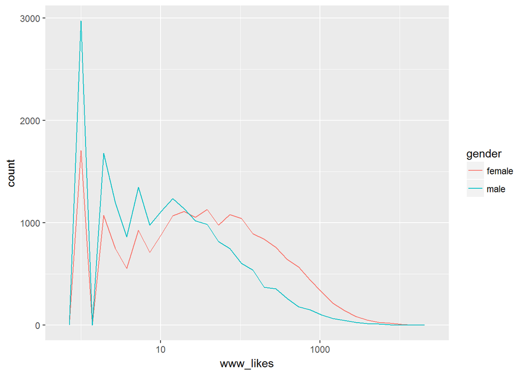

```r
ggplot(aes(x = www_likes), data = subset(pf, !is.na(gender))) +
  geom_freqpoly(aes(color = gender)) +
  scale_x_log10()
```

### Box Plots

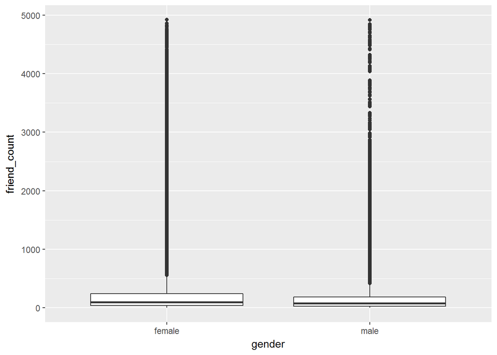

```r
qplot(x = gender, y = friend_count,
      data = subset(pf, !is.na(gender)),
      geom = 'boxplot')
```

Notes: The boxes above for both male and female cover the middle 50% of the values. Each of the tiny little dots are outliers of the data. The horizontal line in the boxes are the median for the boxplots

#### Adjust the code to focus on users who have friend counts between 0 and 1000.

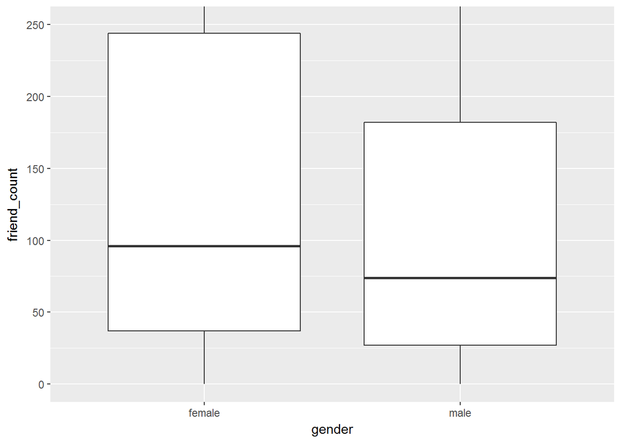

```r
qplot(x = gender, y = friend_count,
      data = subset(pf, !is.na(gender)),
      geom = 'boxplot')+
 coord_cartesian(ylim = c(0,250))
```

Note: Females have higher friend count.

```r
by(pf$friend_count, pf$gender, summary)
```

```
## pf$gender: female
##    Min. 1st Qu.  Median    Mean 3rd Qu.    Max.
##       0      37      96     242     244    4923
## --------------------------------------------------------
## pf$gender: male
##    Min. 1st Qu.  Median    Mean 3rd Qu.    Max.
##       0      27      74     165     182    4917
```

For female: Obs 3rd quartile is at 244 this means the 75% of women have friend_counts below 244.Or 25% of female users have more than 244 friends.

### Box Plots, Quartiles, and Friendships

Notes:

#### On average, who initiated more friendships in our sample: men or women?

```r
by(pf$friendships_initiated, pf$gender, summary)
```

```
## pf$gender: female
##    Min. 1st Qu.  Median    Mean 3rd Qu.    Max.
##     0.0    19.0    49.0   113.9   124.8  3654.0
## --------------------------------------------------------
## pf$gender: male
##    Min. 1st Qu.  Median    Mean 3rd Qu.    Max.
##     0.0    15.0    44.0   103.1   111.0  4144.0
```

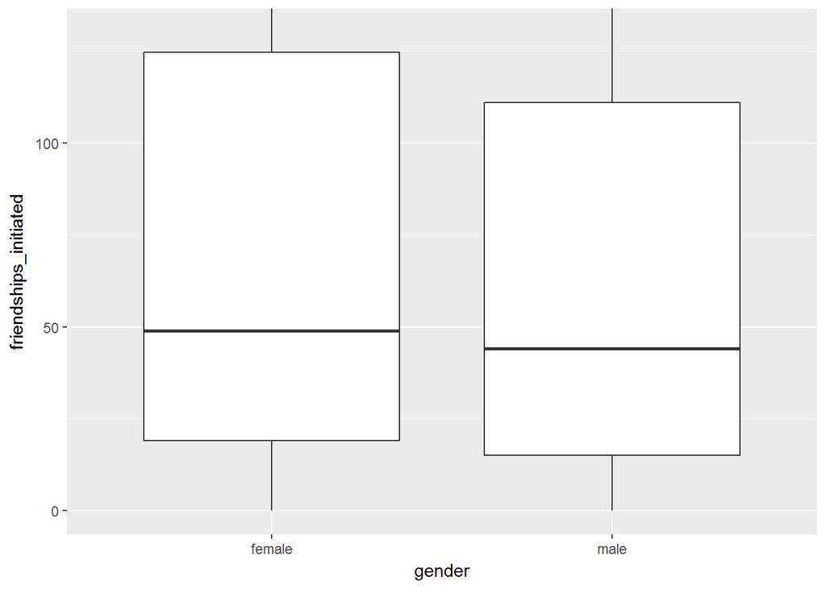

```r
qplot(x = gender, y = friendships_initiated, data = subset(pf, !is.na(gender)),
      geom = 'boxplot') +
  coord_cartesian(ylim = c(0,130))
```

### Getting Logical

Notes:

```r
mobile_check_in <- NA
pf$mobile_check_in <- ifelse(pf$mobile_likes>0,1,0)
pf$mobile_check_in <- factor(pf$mobile_check_in)
summary(pf$mobile_check_in)
```

```
##     0     1
## 35056 63947
```

What percent of users use mobile check in? Find programmatically : 64.5%

```r
sum(pf$mobile_check_in == 1)/length(pf$mobile_check_in)
```

```
## [1] 0.6459097
```

Click **KnitHTML** to see all of your hard work and to have an html page of this lesson, your answers, and your notes!